# Risk Factor Analysis

## Outcome Variable

**Outcome Variable:** whz

## Predictor Variables

**Intervention Variable:** rain_quartile

**Adjustment Set:**

unadjusted

## Stratifying Variables

The analysis was stratified on these variable(s):

- studyid
- country

## Data Summary

| studyid | country | rain_quartile | n_cell | n |
| --- | --- | --- | --- | --- |
| CMC-V-BCS-2002 | India | Opposite max rain | 2170 | 8697 |
| CMC-V-BCS-2002 | India | Post-max rain | 2195 | 8697 |
| CMC-V-BCS-2002 | India | Pre-max rain | 2126 | 8697 |
| CMC-V-BCS-2002 | India | Max rain | 2206 | 8697 |
| CMIN | Bangladesh | Opposite max rain | 1284 | 5372 |
| CMIN | Bangladesh | Post-max rain | 1378 | 5372 |
| CMIN | Bangladesh | Pre-max rain | 1336 | 5372 |
| CMIN | Bangladesh | Max rain | 1374 | 5372 |
| CONTENT | Peru | Opposite max rain | 2150 | 8339 |
| CONTENT | Peru | Post-max rain | 2136 | 8339 |
| CONTENT | Peru | Pre-max rain | 2023 | 8339 |
| CONTENT | Peru | Max rain | 2030 | 8339 |
| EE | Pakistan | Opposite max rain | 1987 | 8427 |
| EE | Pakistan | Post-max rain | 2202 | 8427 |
| EE | Pakistan | Pre-max rain | 2106 | 8427 |
| EE | Pakistan | Max rain | 2132 | 8427 |
| GMS-Nepal | Nepal | Opposite max rain | 3315 | 13340 |
| GMS-Nepal | Nepal | Post-max rain | 3414 | 13340 |
| GMS-Nepal | Nepal | Pre-max rain | 3116 | 13340 |
| GMS-Nepal | Nepal | Max rain | 3495 | 13340 |
| Guatemala BSC | Guatemala | Opposite max rain | 692 | 2545 |
| Guatemala BSC | Guatemala | Post-max rain | 646 | 2545 |
| Guatemala BSC | Guatemala | Pre-max rain | 607 | 2545 |
| Guatemala BSC | Guatemala | Max rain | 600 | 2545 |
| IRC | India | Opposite max rain | 2436 | 9729 |
| IRC | India | Post-max rain | 2490 | 9729 |
| IRC | India | Pre-max rain | 2345 | 9729 |
| IRC | India | Max rain | 2458 | 9729 |
| JiVitA-3 | Bangladesh | Opposite max rain | 29776 | 102950 |
| JiVitA-3 | Bangladesh | Post-max rain | 25759 | 102950 |

[output cut: 58 more lines]

The following strata were considered:

- studyid: CMC-V-BCS-2002, country: India
- studyid: CMIN, country: Bangladesh
- studyid: CONTENT, country: Peru
- studyid: EE, country: Pakistan
- studyid: GMS-Nepal, country: Nepal
- studyid: Guatemala BSC, country: Guatemala
- studyid: IRC, country: India
- studyid: JiVitA-3, country: Bangladesh
- studyid: JiVitA-4, country: Bangladesh
- studyid: Keneba, country: Gambia
- studyid: MAL-ED, country: Bangladesh
- studyid: MAL-ED, country: Brazil
- studyid: MAL-ED, country: India
- studyid: MAL-ED, country: Nepal
- studyid: MAL-ED, country: Peru
- studyid: MAL-ED, country: South Africa
- studyid: MAL-ED, country: Tanzania
- studyid: PROVIDE, country: Bangladesh
- studyid: ResPak, country: Pakistan
- studyid: SAS-CompFeed, country: India
- studyid: SAS-FoodSuppl, country: India
- studyid: TanzaniaChild2, country: Tanzania

## Methods Detail

We’re interested in the causal parameters $E[Y_a]$ for all values of $a \in \mathcal{A}$. These parameters represent the mean outcome if, possibly contrary to fact, we intervened to set all units to have $A=a$. Under the randomization and positivity assumptions, these are identified by the statistical parameters $\psi_a=E_W[E_{Y|A,W}(Y|A=a,W)]$. In addition, we’re interested in the mean of $Y$, $E[Y]$ under no intervention (the observed mean). We will estimate these parameters by using SuperLearner to fit the relevant likelihood factors – $E_{Y|A,W}(Y|A=a,W)$ and $p(A=a|W)$, and then updating our likelihood fit using a joint TMLE.

For unadjusted analyses ($W=\{\}$), initial likelihoods were estimated using Lrnr_glm to estimate the simple $E(Y|A)$ and Lrnr_mean to estimate $p(A)$. For adjusted analyses, a small library containing Lrnr_glmnet, Lrnr_xgboost, and Lrnr_mean was used.

Having estimated these parameters, we will then use the delta method to estimate relative risks and attributable risks relative to a prespecified baseline level of $A$.

# Results Detail

## Results Plots

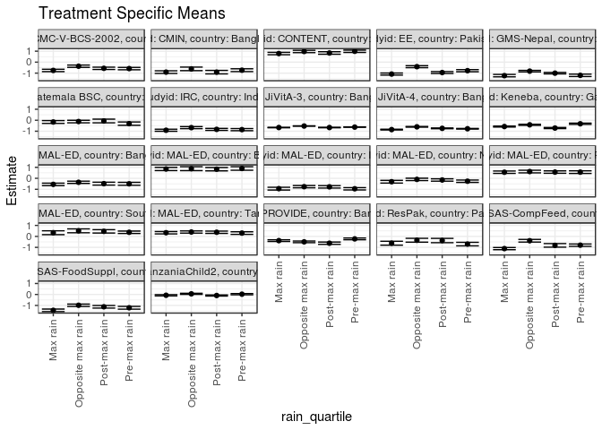

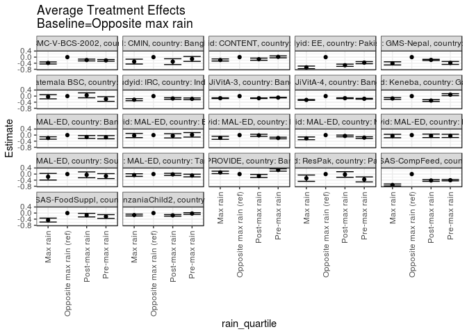

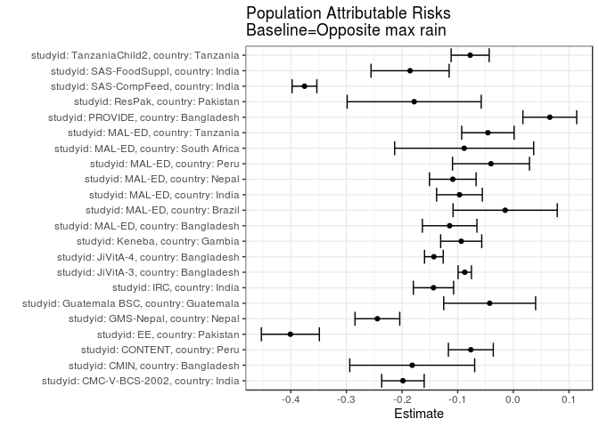

## Results Table

### Parameter: TSM

| studyid | country | intervention_level | baseline_level | estimate | ci_lower | ci_upper |
| --- | --- | --- | --- | --- | --- | --- |
| CMC-V-BCS-2002 | India | Opposite max rain | NA | -0.3706037 | -0.4747263 | -0.2664811 |
| CMC-V-BCS-2002 | India | Post-max rain | NA | -0.5619180 | -0.6690215 | -0.4548145 |
| CMC-V-BCS-2002 | India | Pre-max rain | NA | -0.5861571 | -0.6955011 | -0.4768131 |
| CMC-V-BCS-2002 | India | Max rain | NA | -0.7547461 | -0.8618839 | -0.6476084 |
| CMIN | Bangladesh | Opposite max rain | NA | -0.6135280 | -0.7746471 | -0.4524090 |
| CMIN | Bangladesh | Post-max rain | NA | -0.9119086 | -1.0720185 | -0.7517986 |
| CMIN | Bangladesh | Pre-max rain | NA | -0.7329716 | -0.8600410 | -0.6059022 |
| CMIN | Bangladesh | Max rain | NA | -0.9086754 | -1.0275062 | -0.7898446 |
| CONTENT | Peru | Opposite max rain | NA | 0.9731163 | 0.8665883 | 1.0796443 |
| CONTENT | Peru | Post-max rain | NA | 0.8370646 | 0.7233972 | 0.9507320 |
| CONTENT | Peru | Pre-max rain | NA | 0.9918339 | 0.8852918 | 1.0983760 |
| CONTENT | Peru | Max rain | NA | 0.7838818 | 0.6746891 | 0.8930744 |
| EE | Pakistan | Opposite max rain | NA | -0.4121641 | -0.5032110 | -0.3211172 |
| EE | Pakistan | Post-max rain | NA | -0.9463397 | -1.0338515 | -0.8588279 |
| EE | Pakistan | Pre-max rain | NA | -0.7753324 | -0.8717669 | -0.6788978 |
| EE | Pakistan | Max rain | NA | -1.0855629 | -1.1784370 | -0.9926888 |
| GMS-Nepal | Nepal | Opposite max rain | NA | -0.8186787 | -0.8842050 | -0.7531525 |
| GMS-Nepal | Nepal | Post-max rain | NA | -1.0027973 | -1.0679634 | -0.9376312 |
| GMS-Nepal | Nepal | Pre-max rain | NA | -1.2017651 | -1.3095576 | -1.0939726 |
| GMS-Nepal | Nepal | Max rain | NA | -1.2300029 | -1.3390084 | -1.1209973 |
| Guatemala BSC | Guatemala | Opposite max rain | NA | -0.1188006 | -0.2340853 | -0.0035159 |
| Guatemala BSC | Guatemala | Post-max rain | NA | -0.0677864 | -0.2354149 | 0.0998421 |
| Guatemala BSC | Guatemala | Pre-max rain | NA | -0.3109885 | -0.4617284 | -0.1602485 |
| Guatemala BSC | Guatemala | Max rain | NA | -0.1598833 | -0.2887454 | -0.0310212 |
| IRC | India | Opposite max rain | NA | -0.6754639 | -0.7697086 | -0.5812191 |
| IRC | India | Post-max rain | NA | -0.8327309 | -0.9243528 | -0.7411091 |
| IRC | India | Pre-max rain | NA | -0.8554925 | -0.9531436 | -0.7578415 |
| IRC | India | Max rain | NA | -0.9125753 | -1.0055027 | -0.8196478 |
| JiVitA-3 | Bangladesh | Opposite max rain | NA | -0.5283329 | -0.5474073 | -0.5092585 |
| JiVitA-3 | Bangladesh | Post-max rain | NA | -0.6661961 | -0.6854385 | -0.6469537 |

[output cut: 58 more lines]

### Parameter: E(Y)

| studyid | country | intervention_level | baseline_level | estimate | ci_lower | ci_upper |
| --- | --- | --- | --- | --- | --- | --- |
| CMC-V-BCS-2002 | India | NA | NA | -0.5690192 | -0.6692214 | -0.4688170 |
| CMIN | Bangladesh | NA | NA | -0.7952625 | -0.9007497 | -0.6897752 |
| CONTENT | Peru | NA | NA | 0.8967418 | 0.7963679 | 0.9971157 |
| EE | Pakistan | NA | NA | -0.8128729 | -0.8951633 | -0.7305825 |
| GMS-Nepal | Nepal | NA | NA | -1.0630457 | -1.1281751 | -0.9979164 |
| Guatemala BSC | Guatemala | NA | NA | -0.1613752 | -0.2624299 | -0.0603206 |
| IRC | India | NA | NA | -0.8190122 | -0.9060940 | -0.7319304 |
| JiVitA-3 | Bangladesh | NA | NA | -0.6156438 | -0.6299537 | -0.6013338 |
| JiVitA-4 | Bangladesh | NA | NA | -0.7447431 | -0.7723808 | -0.7171055 |
| Keneba | Gambia | NA | NA | -0.5115077 | -0.5457987 | -0.4772167 |
| MAL-ED | Bangladesh | NA | NA | -0.4763108 | -0.5786381 | -0.3739835 |
| MAL-ED | Brazil | NA | NA | 0.8645917 | 0.7265176 | 1.0026658 |
| MAL-ED | India | NA | NA | -0.8588782 | -0.9568230 | -0.7609334 |
| MAL-ED | Nepal | NA | NA | -0.2062564 | -0.3092655 | -0.1032473 |
| MAL-ED | Peru | NA | NA | 0.5754562 | 0.4819004 | 0.6690119 |
| MAL-ED | South Africa | NA | NA | 0.4196651 | 0.3092932 | 0.5300369 |
| MAL-ED | Tanzania | NA | NA | 0.3527782 | 0.2582437 | 0.4473127 |
| PROVIDE | Bangladesh | NA | NA | -0.4309052 | -0.4946536 | -0.3671569 |
| ResPak | Pakistan | NA | NA | -0.5293078 | -0.6629147 | -0.3957010 |
| SAS-CompFeed | India | NA | NA | -0.7723793 | -0.8890904 | -0.6556682 |
| SAS-FoodSuppl | India | NA | NA | -1.1705178 | -1.2564934 | -1.0845422 |
| TanzaniaChild2 | Tanzania | NA | NA | -0.0208120 | -0.0614288 | 0.0198047 |

### Parameter: ATE

| studyid | country | intervention_level | baseline_level | estimate | ci_lower | ci_upper |
| --- | --- | --- | --- | --- | --- | --- |
| CMC-V-BCS-2002 | India | Opposite max rain | Opposite max rain | 0.0000000 | 0.0000000 | 0.0000000 |
| CMC-V-BCS-2002 | India | Post-max rain | Opposite max rain | -0.1913143 | -0.2507425 | -0.1318861 |
| CMC-V-BCS-2002 | India | Pre-max rain | Opposite max rain | -0.2155534 | -0.2728704 | -0.1582364 |
| CMC-V-BCS-2002 | India | Max rain | Opposite max rain | -0.3841425 | -0.4518567 | -0.3164282 |
| CMIN | Bangladesh | Opposite max rain | Opposite max rain | 0.0000000 | 0.0000000 | 0.0000000 |
| CMIN | Bangladesh | Post-max rain | Opposite max rain | -0.2983805 | -0.4884731 | -0.1082879 |
| CMIN | Bangladesh | Pre-max rain | Opposite max rain | -0.1194435 | -0.2815198 | 0.0426328 |
| CMIN | Bangladesh | Max rain | Opposite max rain | -0.2951474 | -0.4542986 | -0.1359962 |
| CONTENT | Peru | Opposite max rain | Opposite max rain | 0.0000000 | 0.0000000 | 0.0000000 |
| CONTENT | Peru | Post-max rain | Opposite max rain | -0.1360517 | -0.2069381 | -0.0651652 |
| CONTENT | Peru | Pre-max rain | Opposite max rain | 0.0187176 | -0.0449597 | 0.0823949 |
| CONTENT | Peru | Max rain | Opposite max rain | -0.1892345 | -0.2587761 | -0.1196929 |
| EE | Pakistan | Opposite max rain | Opposite max rain | 0.0000000 | 0.0000000 | 0.0000000 |
| EE | Pakistan | Post-max rain | Opposite max rain | -0.5341756 | -0.6077901 | -0.4605612 |
| EE | Pakistan | Pre-max rain | Opposite max rain | -0.3631683 | -0.4326764 | -0.2936602 |
| EE | Pakistan | Max rain | Opposite max rain | -0.6733988 | -0.7569713 | -0.5898262 |
| GMS-Nepal | Nepal | Opposite max rain | Opposite max rain | 0.0000000 | 0.0000000 | 0.0000000 |
| GMS-Nepal | Nepal | Post-max rain | Opposite max rain | -0.1841186 | -0.2219417 | -0.1462955 |
| GMS-Nepal | Nepal | Pre-max rain | Opposite max rain | -0.3830864 | -0.4793404 | -0.2868323 |
| GMS-Nepal | Nepal | Max rain | Opposite max rain | -0.4113241 | -0.5150893 | -0.3075589 |
| Guatemala BSC | Guatemala | Opposite max rain | Opposite max rain | 0.0000000 | 0.0000000 | 0.0000000 |
| Guatemala BSC | Guatemala | Post-max rain | Opposite max rain | 0.0510142 | -0.1107678 | 0.2127962 |
| Guatemala BSC | Guatemala | Pre-max rain | Opposite max rain | -0.1921879 | -0.3444242 | -0.0399516 |
| Guatemala BSC | Guatemala | Max rain | Opposite max rain | -0.0410828 | -0.1786421 | 0.0964766 |
| IRC | India | Opposite max rain | Opposite max rain | 0.0000000 | 0.0000000 | 0.0000000 |
| IRC | India | Post-max rain | Opposite max rain | -0.1572670 | -0.2094358 | -0.1050983 |
| IRC | India | Pre-max rain | Opposite max rain | -0.1800287 | -0.2377227 | -0.1223346 |
| IRC | India | Max rain | Opposite max rain | -0.2371114 | -0.3028829 | -0.1713399 |
| JiVitA-3 | Bangladesh | Opposite max rain | Opposite max rain | 0.0000000 | 0.0000000 | 0.0000000 |
| JiVitA-3 | Bangladesh | Post-max rain | Opposite max rain | -0.1378632 | -0.1581173 | -0.1176091 |

[output cut: 58 more lines]

### Parameter: PAR

| studyid | country | intervention_level | baseline_level | estimate | ci_lower | ci_upper |
| --- | --- | --- | --- | --- | --- | --- |
| CMC-V-BCS-2002 | India | Opposite max rain | NA | -0.1984155 | -0.2365984 | -0.1602327 |
| CMIN | Bangladesh | Opposite max rain | NA | -0.1817344 | -0.2939837 | -0.0694852 |
| CONTENT | Peru | Opposite max rain | NA | -0.0763745 | -0.1167278 | -0.0360211 |
| EE | Pakistan | Opposite max rain | NA | -0.4007088 | -0.4528331 | -0.3485846 |
| GMS-Nepal | Nepal | Opposite max rain | NA | -0.2443670 | -0.2846031 | -0.2041309 |
| Guatemala BSC | Guatemala | Opposite max rain | NA | -0.0425747 | -0.1251627 | 0.0400134 |
| IRC | India | Opposite max rain | NA | -0.1435484 | -0.1797307 | -0.1073660 |
| JiVitA-3 | Bangladesh | Opposite max rain | NA | -0.0873109 | -0.0993102 | -0.0753115 |
| JiVitA-4 | Bangladesh | Opposite max rain | NA | -0.1428422 | -0.1596157 | -0.1260688 |
| Keneba | Gambia | Opposite max rain | NA | -0.0937020 | -0.1306165 | -0.0567876 |
| MAL-ED | Bangladesh | Opposite max rain | NA | -0.1144758 | -0.1634768 | -0.0654747 |
| MAL-ED | Brazil | Opposite max rain | NA | -0.0147221 | -0.1083812 | 0.0789370 |
| MAL-ED | India | Opposite max rain | NA | -0.0968346 | -0.1379421 | -0.0557271 |
| MAL-ED | Nepal | Opposite max rain | NA | -0.1088411 | -0.1507400 | -0.0669422 |
| MAL-ED | Peru | Opposite max rain | NA | -0.0401903 | -0.1093597 | 0.0289790 |
| MAL-ED | South Africa | Opposite max rain | NA | -0.0883805 | -0.2132792 | 0.0365181 |
| MAL-ED | Tanzania | Opposite max rain | NA | -0.0456991 | -0.0928335 | 0.0014352 |
| PROVIDE | Bangladesh | Opposite max rain | NA | 0.0655045 | 0.0171406 | 0.1138684 |
| ResPak | Pakistan | Opposite max rain | NA | -0.1781881 | -0.2986388 | -0.0577374 |
| SAS-CompFeed | India | Opposite max rain | NA | -0.3753683 | -0.3975997 | -0.3531369 |
| SAS-FoodSuppl | India | Opposite max rain | NA | -0.1855701 | -0.2557668 | -0.1153735 |
| TanzaniaChild2 | Tanzania | Opposite max rain | NA | -0.0776131 | -0.1117601 | -0.0434662 |